# Predicting Two-Year Patient Survival from Echocardiogram Data

Raghavendra Prasad Savada

- Introduction
- Understanding the Data
- Data Preparation
- Data Exploration
  - Missing Values
  - Distribution of Variables
  - Outliers
  - Feature Scaling
  - Correlation Among Features
- Predictive Modeling
  - Train-Test Split
  - Impute Missing Values
  - Scale Features
  - Logistic Regression (Model 1/Benchmark Model)
  - Logistic Regression Hyper-parameter Tuning
  - Logistic Regression Model Evaluation
- Selection of Model (Algorithm)
  - Decision Tree (Model 2/Final Chosen Algorithm)
  - Decision Tree Hyper-parameter Tuning
  - Decision Tree Model Evaluation
- Predicting New Unseen Data
- Conclusion
- Further Improvement of the Model

## Introduction

In this project, I trained and tested a classifier using echocardiogram data to predict whether a patient will survive at least two years after a heart-attack. More details about the project is available in the file `project_report.pdf`.

## Understanding the Data

```python
# Import libraries
import pandas as pd
import numpy as np
import matplotlib.pyplot as plt
import seaborn as sns
```

```python
# Read data
df_echo = pd.read_csv("echocardiogram.data", header=None)
```

```python
# Get the names of the columns.
import re
col_names = []
with open('echocardiogram.names') as f_in:
    for line in f_in:
        if re.match(r'\d+\.', line):
            match = re.search(r'\d+\. (\b.*\b) -- ', line)
            col_names.append(match.group(1))
df_echo.columns = col_names
```

```python
df_echo.head()
```

|  | survival | still-alive | age-at-heart-attack | pericardial-effusion | fractional-shortening | epss | lvdd | wall-motion-score | wall-motion-index | mult | name | group | alive-at-1 |
| --- | --- | --- | --- | --- | --- | --- | --- | --- | --- | --- | --- | --- | --- |
| 0 | 11.0 | 0 | 71 | 0 | 0.260 | 9 | 4.600 | 14 | 1 | 1 | name | 1 | 0 |
| 1 | 19.0 | 0 | 72 | 0 | 0.380 | 6 | 4.100 | 14 | 1.700 | 0.588 | name | 1 | 0 |
| 2 | 16.0 | 0 | 55 | 0 | 0.260 | 4 | 3.420 | 14 | 1 | 1 | name | 1 | 0 |
| 3 | 57.0 | 0 | 60 | 0 | 0.253 | 12.062 | 4.603 | 16 | 1.450 | 0.788 | name | 1 | 0 |
| 4 | 19.0 | 1 | 57 | 0 | 0.160 | 22 | 5.750 | 18 | 2.250 | 0.571 | name | 1 | 0 |

```python
# Number of rows and columns
df_echo.shape
```

```
(110, 13)
```

```python
df_echo.info()
```

```
<class 'pandas.core.frame.DataFrame'>
RangeIndex: 110 entries, 0 to 109
Data columns (total 13 columns):
 #   Column                 Non-Null Count  Dtype
---  ------                 --------------  -----
 0   survival               110 non-null    float64
 1   still-alive            110 non-null    int64
 2   age-at-heart-attack    110 non-null    object
 3   pericardial-effusion   110 non-null    int64
 4   fractional-shortening  110 non-null    object
 5   epss                   110 non-null    object
 6   lvdd                   110 non-null    object
 7   wall-motion-score      110 non-null    object
 8   wall-motion-index      110 non-null    object
 9   mult                   110 non-null    object
 10  name                   110 non-null    object
 11  group                  110 non-null    object
 12  alive-at-1             110 non-null    object
dtypes: float64(1), int64(2), object(10)
memory usage: 11.3+ KB
```

## Data Preparation

```python
# Missing values are represented as '?'.
# Change them to np.nap for programmatic handling of the missing values
df_echo = df_echo.replace('?', np.nan)
```

```python
# Change the datatype of columns to suitable datatype
df_echo = df_echo.astype(dtype={'age-at-heart-attack':'float',
                                'fractional-shortening':'float',
                                'epss':'float',
                                'lvdd':'float',
                                'wall-motion-score':'float',
                                'wall-motion-index':'float',
                                'mult':'float',
                                })
```

```python
df_echo.info()
```

```
<class 'pandas.core.frame.DataFrame'>
RangeIndex: 110 entries, 0 to 109
Data columns (total 13 columns):
 #   Column                 Non-Null Count  Dtype
---  ------                 --------------  -----
 0   survival               110 non-null    float64
 1   still-alive            110 non-null    int64
 2   age-at-heart-attack    108 non-null    float64
 3   pericardial-effusion   110 non-null    int64
 4   fractional-shortening  103 non-null    float64
 5   epss                   96 non-null     float64
 6   lvdd                   100 non-null    float64
 7   wall-motion-score      107 non-null    float64
 8   wall-motion-index      109 non-null    float64
 9   mult                   107 non-null    float64
 10  name                   110 non-null    object
 11  group                  108 non-null    object
 12  alive-at-1             73 non-null     object
dtypes: float64(8), int64(2), object(3)
memory usage: 11.3+ KB
```

```python
# Descriptive statistics
df_echo.describe()
```

|  | survival | still-alive | age-at-heart-attack | pericardial-effusion | fractional-shortening | epss | lvdd | wall-motion-score | wall-motion-index | mult |
| --- | --- | --- | --- | --- | --- | --- | --- | --- | --- | --- |
| count | 110.000000 | 110.000000 | 108.000000 | 110.000000 | 103.000000 | 96.000000 | 100.000000 | 107.000000 | 109.000000 | 107.000000 |
| mean | 21.238909 | 0.363636 | 63.245639 | 0.172727 | 0.216845 | 12.446646 | 4.770820 | 14.597290 | 1.398541 | 0.779065 |
| std | 16.620949 | 0.483247 | 8.756683 | 0.379741 | 0.111736 | 7.058968 | 0.799371 | 5.270048 | 0.473960 | 0.214852 |
| min | 0.030000 | 0.000000 | 35.000000 | 0.000000 | 0.010000 | 0.000000 | 3.100000 | 2.000000 | 1.000000 | 0.140000 |
| 25% | 3.250000 | 0.000000 | 57.000000 | 0.000000 | 0.145000 | 7.400000 | 4.230000 | 11.250000 | 1.000000 | 0.710000 |
| 50% | 22.000000 | 0.000000 | 63.000000 | 0.000000 | 0.217000 | 11.350000 | 4.626500 | 14.000000 | 1.222000 | 0.786000 |
| 75% | 33.000000 | 1.000000 | 68.250000 | 0.000000 | 0.271000 | 16.175000 | 5.302500 | 16.835000 | 1.625000 | 0.857000 |
| max | 57.000000 | 1.000000 | 86.000000 | 1.000000 | 0.610000 | 40.000000 | 6.780000 | 39.000000 | 3.000000 | 2.000000 |

#### Removing rows/observations that cannot be used in prediction

Remove all the rows where patient is still alive, but had heart attack less than 24 months ago. Since we are interested in predicting whether a patient will survive at least 2 years, we cannot include these rows in model training. Becuase, we would not know whehter these patients are going to survive for at least two years or not.

```python
df_echo_filtered = df_echo[~((df_echo['still-alive'] == 1) & (df_echo['survival'] < 24))]
```

```python
df_echo_filtered.shape
```

```
(71, 13)
```

#### Creating a target variable that indicates weather a patient survived for at least 2 years (1) or not(0)

```python
# If the survival column has a value more than equal to 24,
# label them as 1 in target column
target = (df_echo_filtered['survival'] >= 24).astype(int)
```

#### Is dataset balanced?

As can be seen below, the dataset is highly imbalanced.

```python
# Is target variable balanced?
target.value_counts()
```

```
1    52
0    19
Name: survival, dtype: int64
```

#### Create a dataframe of variables that will be used as features in the training

We cannot use the following variables as features in the training for the reasons mentioned below.

- `wall-motion-score`: it is recommended to use `wall-motion-index` instead of this variable.
- `mult`: it is suggested to ignore this variable.
- `name`: the name of the patient (replaced them with "name"), so we are suggested to ignore it.
- `group`: It is suggested to ignore this variable as it is meaningless.
- `survival` and `still-alive`: these two variables are used to derive the target variable and hence encode the target variable. So, we cannot use them in the training.
- `alive-at-1`: we cannot use this in training because in the future when we want to make predictions, we will not have this data. I did not use this variable to make any other decision during data preparation. Because,
  - This variable does not seem to be extracted correctly. For instance,
    - In some rows, `survival` column has values greater than 12, which indicates that patient was alive after 1 year. But value in `alive-at-1` column is 0 (value should have been 1).
    - In some rows, patient is still alive as per the `still-alive` column, and survived for less than 12 months as per the `survival` column. But value in `alive-at-1` is 1 (we can not determine this value).
    - In some rows, we know patient survived for more than 12 months. Still the value in `alive-at-1` is missing. In these cases the value should have been 1. Simiraly, in some rows, we know that the patient died before 12 months, so the value should have been 0, but the value is missing in dataset.
    - Variable description says *0 means patient was either dead after 1 year or had been followed for less than 1 year.* This could mean two things;
      - Patient had heart attack less than one year ago, so had been followed for less than 1 year. Or
      - hospital lost touch with the patient within 1 year (e.g., patient moved to a different state/country) and do not know the status of the patient. I considered the scenario 1 above to be true. If scenario 2 is true, in the rows where `alive-at-1` is 0, I would not know whether patient is dead or we just do not have information about these patients. This raises the question about validity of the data in first two columns as well. Since, description says this column is derived from first two attributes,I ignored this variable, and created my target variable based on the information in `survival` and `still-alive` columns.

```python
# Drop unwanted columns
features = df_echo_filtered.drop(['survival', 'still-alive', 'wall-motion-score',
                                  'mult', 'name', 'group', 'alive-at-1'], axis = 1)
features.shape
```

```
(71, 6)
```

## Data Exploration

### Missing Values

As can be seen below, there are a few missing values in three of the features. We can handle the missing values in one of the following ways:

1. Delete observations with missing value: since it is a small dataset, this is not a good option.
2. Recover the missing value; not possible in this context.
3. Imputation:
   - Educated guessing: need good domain expertise to handle missing values in this way.
   - Mean/median/mode imputation (single or multiple imputation).
   - Using trend in the data to impute missing values. This is especially useful in time series analysis.
   - Using regression or other machine learning algorithms to predict missing values: this is time consuming.

I am going to use mean imputation to fill missing values in the variables. All the data pre-processing like imputation, feature scaling will be done after splitting the data into training and test set.

```python
# Number of missing values in each feature
features.isnull().sum()
```

```
age-at-heart-attack      0
pericardial-effusion     0
fractional-shortening    3
epss                     8
lvdd                     3
wall-motion-index        0
dtype: int64
```

### Distribution of Variables

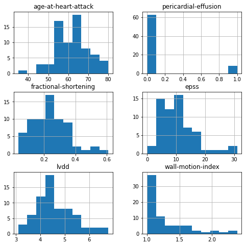

```python
# Plot histograms of features
features.hist(figsize=(8,8));
```

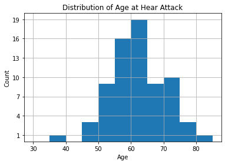

```python
features['age-at-heart-attack'].hist(bins=np.linspace(30, 85, 12))
plt.title('Distribution of Age at Hear Attack')
plt.xlabel('Age')
plt.ylabel('Count')
plt.yticks(range(1, 20, 3));
```

### Outliers

As can be seen in the boxplots below, there are a few outliers in each of the variables. Outliers could represent one of the following:

- Errors in data collection.
- They are legitimate value and may signify a trend.

If second scenario above is true, we may want to retain the outliers. It is difficult to determine which of the above scenarios is true. So I do not remove any outliers.

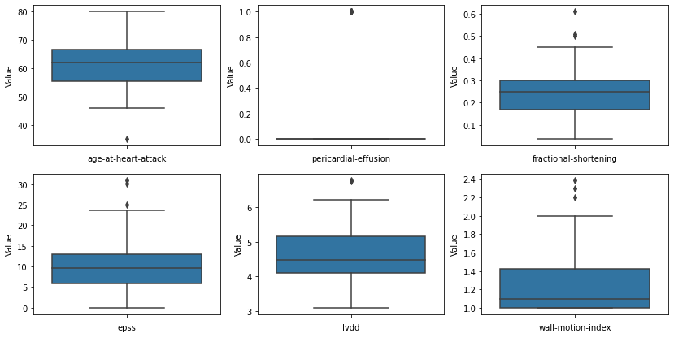

```python
# Plot boxplots of features
fig = plt.figure(figsize=(14, 7))
for i, j in enumerate(features.columns):
    ax = fig.add_subplot(2, 3, i+1)
    sns.boxplot(y=features[j])
    plt.xlabel(j)
    plt.ylabel('Value')
```

### Feature Scaling

Feature like `age-at-heart-attack` that can take large values (range: 35-80) may overshadow the effect of features like `fractional-shortening` that takes small values (range: 0.036-0.61). To overcome this, the features will be scaled using StandardScaler, which normalizes the features. The features will be scaled after splitting the data into train and test set.

```python
# Range of different features
features.agg([np.min, np.max])
```

|  | age-at-heart-attack | pericardial-effusion | fractional-shortening | epss | lvdd | wall-motion-index |
| --- | --- | --- | --- | --- | --- | --- |
| amin | 35.0 | 0 | 0.036 | 0.0 | 3.10 | 1.00 |
| amax | 80.0 | 1 | 0.610 | 31.0 | 6.78 | 2.39 |

### Correlation Among Features

Check if any of the features are correlated. If two features are highly correlated, we can remove one of them.

As you can see in the heat map and scatter matrix below, there is a moderate correlation between the following features.

- fractional-shortening and epss
- fractional-shortening and ivdd
- ivdd and epss

Since the correlation is only moderate, I do not remove any of the features.

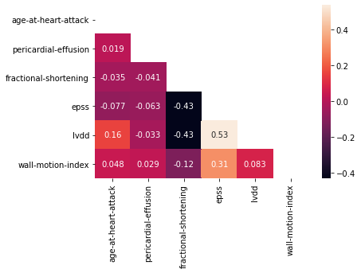

```python
# Find out correlation among features
matrix = np.triu(features.corr())
sns.heatmap(features.corr(), annot=True, mask=matrix);
```

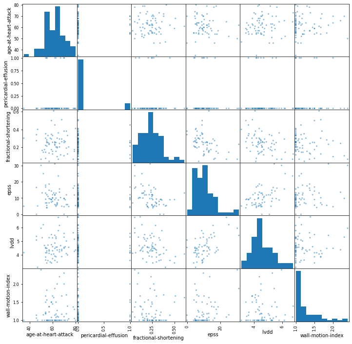

```python
# Plot scatter-matrix of features
pd.plotting.scatter_matrix(features, figsize=(12,12));
```

## Predictive Modeling

### Train-Test Split

```python
# Import train_test_split
from sklearn.model_selection import train_test_split

# Split the data into training and testing sets
X_train, X_test, y_train, y_test = train_test_split(features,
                                                    target,
                                                    test_size=0.25,
                                                    random_state=0,
                                                    shuffle=True)

# Show the results of the split
print("Training set has {} samples.".format(X_train.shape[0]))
print("Testing set has {} samples.".format(X_test.shape[0]))
```

```
Training set has 53 samples.
Testing set has 18 samples.
```

### Impute Missing Values

```python
from sklearn.impute import SimpleImputer
imp = SimpleImputer(missing_values=np.nan, strategy='mean')
imp.fit(X_train)
X_train_imp = imp.transform(X_train)
X_test_imp = imp.transform(X_test) # Use the same imputer that is fit using training data
```

### Scale Features

I have used StdScaler for scaling the features.

```python
from sklearn.preprocessing import StandardScaler
scaler = StandardScaler()
scaler.fit(X_train_imp)
X_train_imp_scaled = scaler.transform(X_train_imp)
X_test_imp_scaled = scaler.transform(X_test_imp) # Use the same scaler that is fit using training data
```

### Logistic Regression (Model 1/Benchmark Model)

First, I will train a simple logistic regression model, which also serves as a benchmark model.

The benchmark models help us to make sure (1) our model is performing better than some trivial models (2) the problem we are working on has a useful target function.

If a previous model exists in the literature or with us, we can use it as a benchmark model. Otherwise we can create a simple model (e.g., linear/logistic regression/decision stumps) that serves as a benchmark model.

### Logistic Regression Hyper-parameter Tuning

```python
from sklearn.model_selection import GridSearchCV
from sklearn.metrics import f1_score, accuracy_score, recall_score, precision_score
from sklearn.metrics import confusion_matrix
from sklearn.metrics import classification_report

# A function to do gridsearch
def fit_model(X, y, clf, params):
    """ Performs grid search on the input data [X, y] using classifier 'clf'
    and parameter grid 'parms'.
    """

    # Create the grid search cv object
    # Since dataset is imbalanced f1_macro is used as evaluation metric
    grid = GridSearchCV(estimator=clf, param_grid=params, scoring='f1_macro', cv=5)

    # Fit the grid search object to the data
    grid = grid.fit(X, y)

    # Return the optimal model after fitting the data
    return grid.best_estimator_
```

```python
from sklearn.linear_model import LogisticRegression
import warnings
warnings.filterwarnings("ignore")
# Initialize the classifier
clf_lr = LogisticRegression(class_weight='balanced', random_state=42)

# Parameter grid
params = {"C": [0.01, 0.1, 1, 10, 100],
         "max_iter":[100, 200],
         "solver":['newton-cg', 'lbfgs', 'liblinear', 'sag', 'saga']}

# Fit the training data to the model using grid search
log_reg = fit_model(X_train_imp_scaled, y_train, clf_lr, params)


# Print the optimal hyperparameters
print("Hyperparameters for the optimal model {}.".format(log_reg.get_params()))
```

```
Hyperparameters for the optimal model {'C': 0.1, 'class_weight': 'balanced', 'dual': False, 'fit_intercept': True, 'intercept_scaling': 1, 'l1_ratio': None, 'max_iter': 100, 'multi_class': 'auto', 'n_jobs': None, 'penalty': 'l2', 'random_state': 42, 'solver': 'newton-cg', 'tol': 0.0001, 'verbose': 0…
```

### Logistic Regression Model Evaluation

```python
def model_evaluation(true, predict):
    """Takes true and predicted labels as input and prints various
    evaluation metrics. Although, F1 Score is main metric used for
    evaluation purpose, this function prints other metrics as well
    for reference purpose.
    """
    print("Accuracy: {:.2f}".format(accuracy_score(true, predict)))
    print("Precision: {:.2f}".format(precision_score(true, predict)))
    print("Recall: {:.2f}".format(recall_score(true, predict)))
    print("f1_macro: {:.2f}".format(f1_score(true, predict, average='macro')))

    print('\nEvaluation Metrics for both classes')
    print('-----------------------------------')
    print(classification_report(true, predict))

    print('\nConfusion Matrix')
    print('-----------------------------------')
    print(pd.DataFrame(confusion_matrix(true, predict), columns=['Predicted_dead', 'Predicted_alive'],
            index=['Actual_dead', 'Actual_alive']))
```

```python
# Make predictions on test set and evaluate performance
predictions_lr = log_reg.predict(X_test_imp_scaled)
model_evaluation(y_test, predictions_lr)
```

```
Accuracy: 0.50
Precision: 0.60
Recall: 0.55
f1_macro: 0.49

Evaluation Metrics for both classes
-----------------------------------
              precision    recall  f1-score   support

           0       0.38      0.43      0.40         7
           1       0.60      0.55      0.57        11

    accuracy                           0.50        18
   macro avg       0.49      0.49      0.49        18
weighted avg       0.51      0.50      0.50        18


Confusion Matrix
-----------------------------------
              Predicted_dead  Predicted_alive
Actual_dead                3                4
Actual_alive               5                6
```

```python
features.columns
```

```
Index(['age-at-heart-attack', 'pericardial-effusion', 'fractional-shortening',
       'epss', 'lvdd', 'wall-motion-index'],
      dtype='object')
```

```python
# Get the coefficients to find out the most important feature
pd.DataFrame({'Features': features.columns, 'Estimated Coefficients': log_reg.coef_[0]})
```

|  | Features | Estimated Coefficients |
| --- | --- | --- |
| 0 | age-at-heart-attack | -0.320106 |
| 1 | pericardial-effusion | -0.165535 |
| 2 | fractional-shortening | -0.041078 |
| 3 | epss | 0.144547 |
| 4 | lvdd | -0.219591 |
| 5 | wall-motion-index | -0.140286 |

## Selection of Model (Algorithm)

In this section, I am going to examine which algorithm works best for this problem. I am going to test several algorithms to see which one works better: since the dataset is small, it is reasonable to test several algorithms.

```python
from sklearn.svm import SVC
from sklearn.neighbors import KNeighborsClassifier
from sklearn.ensemble import AdaBoostClassifier, GradientBoostingClassifier, BaggingClassifier
from sklearn.tree import DecisionTreeClassifier
from sklearn.naive_bayes import GaussianNB
from sklearn.ensemble import RandomForestClassifier
from sklearn.linear_model import SGDClassifier
from sklearn.neural_network import MLPClassifier

# Algorithms to test
clf_a = GaussianNB()
clf_b = DecisionTreeClassifier(random_state=42)
clf_c = SVC(random_state=42, class_weight='balanced')
clf_d = KNeighborsClassifier()
clf_e = SGDClassifier(random_state=42, class_weight='balanced')

# Ensembles
clf_f = BaggingClassifier(random_state=42)
clf_g = RandomForestClassifier(random_state=42, class_weight='balanced')
clf_h = AdaBoostClassifier(random_state=42)
clf_i = GradientBoostingClassifier(random_state=42)

# Deep Learning
clf_j = MLPClassifier(solver='lbfgs', hidden_layer_sizes=(100, 50), random_state=42)
```

```python
# Select algorithm using cross validation
from sklearn.model_selection import cross_val_score

f1_macro_list = []
clf_names = []
for c in [clf_a, clf_b, clf_c, clf_d, clf_e, clf_f, clf_g, clf_h, clf_i, clf_j]:
    scores = cross_val_score(c, X_train_imp_scaled, y_train, cv=5, scoring='f1_macro')
    scores.mean()
    f1_macro_list.append(scores.mean())
    clf_names.append(c.__class__.__name__)
scores = {'clf': clf_names, 'f1_macro': f1_macro_list}
df = pd.DataFrame(scores)
df
```

|  | clf | f1_macro |
| --- | --- | --- |
| 0 | GaussianNB | 0.509488 |
| 1 | DecisionTreeClassifier | 0.627075 |
| 2 | SVC | 0.476097 |
| 3 | KNeighborsClassifier | 0.429663 |
| 4 | SGDClassifier | 0.516686 |
| 5 | BaggingClassifier | 0.596520 |
| 6 | RandomForestClassifier | 0.489336 |
| 7 | AdaBoostClassifier | 0.617908 |
| 8 | GradientBoostingClassifier | 0.491340 |
| 9 | MLPClassifier | 0.437035 |

### Decision Tree (Model 2/Final Chosen Algorithm)

I have tried several algorithms above. Among them, decision tree gave the highest F1 score. So I have chosen Decision tree as my final algorithm.

### Decision Tree Hyper-parameter Tuning

```python
%%time
# Initialize the classifier
clf_dt = DecisionTreeClassifier(random_state=42)

# Parameter grid
params = {'max_depth': [2,4,6,8,10,20,None],
          'max_features': ['auto', 'sqrt', 'log2'],
          'min_samples_leaf': [1,2,4],
          'min_samples_split': [6,8,10]}

# Fit the training data to the model using grid search
dec_tree = fit_model(X_train_imp_scaled, y_train, clf_dt, params)


# Print the optimal hyperparameters
print("Hyperparameters for the optimal model {}.".format(dec_tree.get_params()))
```

```
Hyperparameters for the optimal model {'ccp_alpha': 0.0, 'class_weight': None, 'criterion': 'gini', 'max_depth': 6, 'max_features': 'auto', 'max_leaf_nodes': None, 'min_impurity_decrease': 0.0, 'min_impurity_split': None, 'min_samples_leaf': 2, 'min_samples_split': 8, 'min_weight_fraction_leaf': 0.0…
Wall time: 1.82 s
```

### Decision Tree Model Evaluation

```python
# Make predictions on test set and evaluate performance
predictions_dt = dec_tree.predict(X_test_imp_scaled)
model_evaluation(y_test, predictions_dt)
```

```
Accuracy: 0.61
Precision: 0.70
Recall: 0.64
f1_macro: 0.60

Evaluation Metrics for both classes
-----------------------------------
              precision    recall  f1-score   support

           0       0.50      0.57      0.53         7
           1       0.70      0.64      0.67        11

    accuracy                           0.61        18
   macro avg       0.60      0.60      0.60        18
weighted avg       0.62      0.61      0.61        18


Confusion Matrix
-----------------------------------
              Predicted_dead  Predicted_alive
Actual_dead                4                3
Actual_alive               4                7
```

```python
# Get the feature imporatance
pd.DataFrame({'Features': features.columns, 'Feature Score': dec_tree.feature_importances_})
```

|  | Features | Feature Score |
| --- | --- | --- |
| 0 | age-at-heart-attack | 0.180100 |
| 1 | pericardial-effusion | 0.000000 |
| 2 | fractional-shortening | 0.055811 |
| 3 | epss | 0.286492 |
| 4 | lvdd | 0.000000 |
| 5 | wall-motion-index | 0.477597 |

## Predicting New Unseen Data

In this section, I am going to apply the two models I trained above to `echocardiogram.test` and label this unseen dataset. I preprocessed this data in the same way as I preprocessed the training data.

**Note:** In line 16 of the echocardiogram.test file, there are 14 columns instead of 13. This happened because, in 3rd column, which is supposed to be age-at-heart-attack, a value of 1 is additionally inserted. So, I removed this value. Then every column seems right; for instance, every row in column 11 has the value *name* after this cleaning.

```python
# Read new data
df_echo_new = pd.read_csv("echocardiogram.test", header=None)
df_echo_new.columns = col_names
```

```python
# Change ? to np.nap for programmatic handling of the missing values
df_echo_new = df_echo_new.replace('?', np.nan)
```

```python
# Change the datatype of columns to suitable datatype
df_echo_new = df_echo_new.astype(dtype={'age-at-heart-attack':'float',
                                'fractional-shortening':'float',
                                'epss':'float',
                                'lvdd':'float',
                                'wall-motion-score':'float',
                                'wall-motion-index':'float',
                                'mult':'float',
                                })
```

```python
df_echo_new.head()
```

|  | survival | still-alive | age-at-heart-attack | pericardial-effusion | fractional-shortening | epss | lvdd | wall-motion-score | wall-motion-index | mult | name | group | alive-at-1 |
| --- | --- | --- | --- | --- | --- | --- | --- | --- | --- | --- | --- | --- | --- |
| 0 | NaN | NaN | 61.0 | 0 | 0.27 | 9.0 | 4.06 | 12.0 | 1.00 | 0.857 | name | NaN | NaN |
| 1 | NaN | NaN | 59.0 | 1 | 0.40 | 9.2 | 5.36 | 12.0 | 1.00 | 0.857 | name | NaN | NaN |
| 2 | NaN | NaN | 57.0 | 0 | 0.29 | 9.4 | 4.77 | 9.0 | 1.00 | 0.640 | name | NaN | NaN |
| 3 | NaN | NaN | 62.0 | 1 | 0.19 | 28.9 | 6.63 | 19.5 | 1.95 | 0.714 | name | NaN | NaN |
| 4 | NaN | NaN | NaN | 0 | 0.26 | 0.0 | 4.38 | 9.0 | 1.00 | 0.640 | name | NaN | NaN |

```python
# Drop unwanted columns and create a feature dataframe
features_new = df_echo_new.drop(['survival', 'still-alive', 'wall-motion-score',
                                  'mult', 'name', 'group', 'alive-at-1'], axis = 1)
```

```python
# Range of different features in the unseen data
features_new.agg([np.min, np.max])
```

|  | age-at-heart-attack | pericardial-effusion | fractional-shortening | epss | lvdd | wall-motion-index |
| --- | --- | --- | --- | --- | --- | --- |
| amin | 48.0 | 0 | 0.09 | 0.0 | 2.32 | 1.00 |
| amax | 69.0 | 1 | 0.43 | 28.9 | 6.63 | 1.95 |

```python
# Impute missing values using the same imputer fit using training data earlier.
features_new_imp = imp.transform(features_new)
# Scale features using the same scaler fit using training data earlier
features_new_imp_scaled = scaler.transform(features_new_imp)
```

#### Label New Unseen Data Using Logistic Regression Model

```python
predictions_lr_new = log_reg.predict(features_new_imp_scaled)
```

#### Label New Unseen Data Using Decision Tree Model

```python
predictions_dt_new = dec_tree.predict(features_new_imp_scaled)
```

#### Create a dataset with new unseen data labeled using logistic regression and decision tree model

```python
df_echo_new['Prediction_logistic_regression'] = predictions_lr_new
df_echo_new['Prediction_decision_tree'] = predictions_dt_new
```

```python
# Write new dataset with predictions to a csv file
df_echo_new.to_csv('predictions_unseen_data.csv', index=False)
```

## Conclusion

In this project, I trained a model using echonocardiogram data to predict if a patient will survive for at least two years after a heart attack. I used decision tree algorithm to train the model. This model yielded an F1_macro score of `0.60`. It correctly predicted `4` out of `7` instances (recall `0.57`) in the held-out test data, where the patients died before 2 years. Also, it correctly predicted `7` out of `11` instances (recall `0.64`), where the patients survived at least 2 years.

## Further Improvement of the Model

- One of the greatest limitations in this project is amount of data available for training. To improve the model performance further, we may need more data. Although not guaranteed, ensembles and deep neural networks generally produce better results. But for these algorithms to work well we need more data. As you can see above, in fact random forest, boosting and MLP performed worse than decision tree in this case as dataset is very small.
- Class imbalance is another problem. So, we can also try upsampling the rare class.
- Nested cross validation may also help since amount of data available for training, validation and testing all increases a little bit if we use this technique.
- I think, the following additional features may be helpful.
  - Gender; in the first year after a heart attack, women are more than 50% more likely to die than men are [Reference](https://www.texasheart.org/heart-health/heart-information-center/topics/women-and-heart-disease/).
  - Income: rich people can afford better care after a heart-attack.
  - Area of residence (urban or rural): patients living in urban areas are likely to get faster emergency care in case of subsequent attacks.
  - Occupation: stressful occupation can worsen cardiovascular problems [Reference](https://www.ncbi.nlm.nih.gov/pmc/articles/PMC2822187/).